# Cristobal - FA2 - DMW

2024-02-26

# Cristobal - FA2 - DMW

## MLB Data

### Loading Libraries

```r
library(dplyr)
library(tidyverse)
```

```r
library(ggplot2)
library(tidyr)
library(patchwork)
library(ggrepel)
```

### Loading Dataset

```r
load("ml_pay.rdata")
mlb_data <- ml_pay
```

## Tidying

### Splitting the Dataset into Two Tibbles

#### Aggregate Tibble

```r
mlb_aggregate <- mlb_data %>%
  select(team = Team.name.2014, payroll_aggregate = payroll, pct_wins_aggregate = avgwin)
```

#### Yearly Tibble

```r
mlb_yearly <- mlb_data %>%
  select(team = Team.name.2014, starts_with("p"), starts_with("X")) %>%
  pivot_longer(-team, names_to = "year_metric", values_to = "value") %>%
  mutate(
    year = str_extract(year_metric, "\\d{4}"),
    metric = if_else(str_detect(year_metric, "^p"), "payroll",
                     if_else(str_detect(year_metric, "\\.pct$"), "pct_wins", NA_character_))
  ) %>%
  filter(!is.na(metric)) %>%
  mutate(year = as.numeric(year), value = as.numeric(value)) %>%
  drop_na(value) %>%
  group_by(team, year, metric) %>%
  summarise(value = mean(value), .groups = 'drop') %>%
  pivot_wider(names_from = metric, values_from = value) %>%
  mutate(
    num_wins = if_else(!is.na(pct_wins), round(pct_wins * 162), NA_real_)
  ) %>%
  select(team, year, payroll, pct_wins, num_wins)
```

```r
print(mlb_aggregate)
```

```
##                     team payroll_aggregate pct_wins_aggregate
## 1   Arizona Diamondbacks         1.1208736          0.4902585
## 2         Atlanta Braves         1.3817118          0.5527605
## 3      Baltimore Orioles         1.1612117          0.4538250
## 4         Boston Red Sox         1.9723587          0.5487172
## 5           Chicago Cubs         1.4597668          0.4736557
## 6      Chicago White Sox         1.3153909          0.5111170
## 7        Cincinnati Reds         1.0247816          0.4861602
## 8      Cleveland Indians         0.9991810          0.4959225
## 9       Colorado Rockies         1.0261536          0.4633760
## 10        Detroit Tigers         1.4297408          0.4822029
## 11        Houston Astros         1.0601501          0.4687202
## 12    Kansas City Royals         0.8177417          0.4342288
## 13    Los Angeles Angels         1.5626224          0.5463819
## 14   Los Angeles Dodgers         1.7402719          0.5308482
```

[output cut: 16 more lines]

```r
print(mlb_yearly)
```

```
## # A tibble: 540 × 5
##    team                  year payroll pct_wins num_wins
##    <fct>                <dbl>   <dbl>    <dbl>    <dbl>
##  1 Arizona Diamondbacks  1998    31.6    0.399       65
##  2 Arizona Diamondbacks  1999    70.5    0.613       99
##  3 Arizona Diamondbacks  2000    81.0    0.525       85
##  4 Arizona Diamondbacks  2001    81.2    0.568       92
##  5 Arizona Diamondbacks  2002   103.     0.605       98
##  6 Arizona Diamondbacks  2003    80.6    0.519       84
##  7 Arizona Diamondbacks  2004    70.2    0.315       51
##  8 Arizona Diamondbacks  2005    63.0    0.475       77
##  9 Arizona Diamondbacks  2006    59.7    0.469       76
## 10 Arizona Diamondbacks  2007    52.1    0.552       89
## # … with 530 more rows
```

```r
cat("Rows in mlb_aggregate:", nrow(mlb_aggregate), "\n")
```

```
## Rows in mlb_aggregate: 30
```

```r
cat("Rows in mlb_yearly:", nrow(mlb_yearly), "\n")
```

```
## Rows in mlb_yearly: 540
```

## Quality Control

### Creating Computed and Joined Aggregate Tables

```r
mlb_aggregate_computed <- mlb_yearly %>%
  group_by(team) %>%
  summarise(
    payroll_aggregate_computed = sum(payroll, na.rm = TRUE),
    pct_wins_aggregate_computed = mean(pct_wins, na.rm = TRUE)
  )

mlb_aggregate_joined <- inner_join(mlb_aggregate, mlb_aggregate_computed, by = "team")
```

### Scatterplot: Payroll Comparison and Win Percentage Comparison

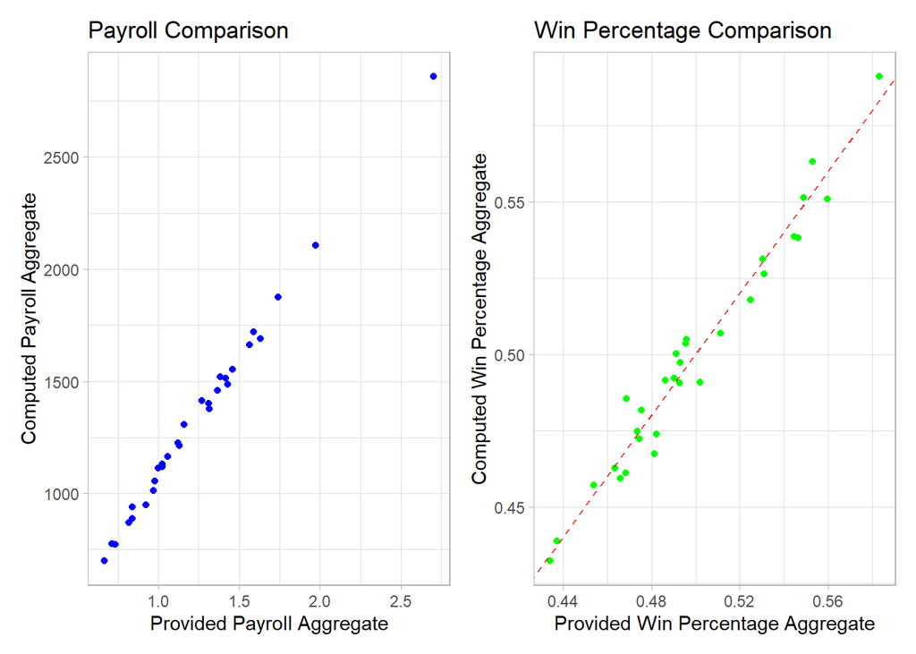

```r
theme_set(theme_light())

# Scatter plot for Payroll
p1 <- ggplot(mlb_aggregate_joined, aes(x = payroll_aggregate, y = payroll_aggregate_computed)) +
  geom_point(color = "blue") +
  geom_abline(intercept = 0, slope = 1, linetype = "dashed", color = "red") +
  labs(x = "Provided Payroll Aggregate", y = "Computed Payroll Aggregate", title = "Payroll Comparison")

# Scatter plot for Win Percentage
p2 <- ggplot(mlb_aggregate_joined, aes(x = pct_wins_aggregate, y = pct_wins_aggregate_computed)) +
  geom_point(color = "green") +
  geom_abline(intercept = 0, slope = 1, linetype = "dashed", color = "red") +
  labs(x = "Provided Win Percentage Aggregate", y = "Computed Win Percentage Aggregate", title = "Win Percentage Comparison")

p1 + p2
```

### Interpretation

#### Payroll Comparison

- The x-axis represents the provided payroll aggregate, and the y-axis represents the computed payroll aggregate.
- The plot shows a positive linear trend, which indicates that as the provided payroll aggregate increases, the computed payroll aggregate also increases. A strong trend can be seen, suggesting that the provided and computed payrolls are consistent with each other. There is one point that lies far away from the main cluster on the top right, which could be an outlier or a team with a particularly high payroll.

### 2.1 Plotting Payroll as a Function of Year for Each Team

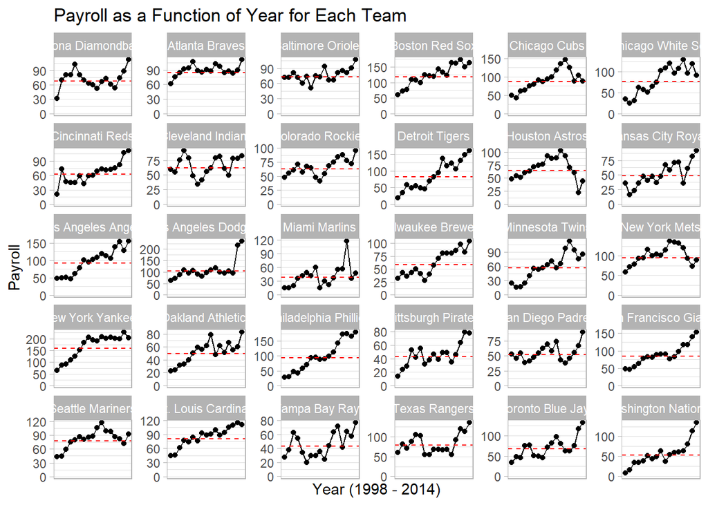

```r
ggplot(mlb_yearly, aes(x = as.numeric(year), y = payroll, group = team)) +
  geom_line() +
  geom_point() +
  geom_hline(data = mlb_yearly %>% group_by(team) %>%
               summarise(mean_payroll = mean(payroll, na.rm = TRUE), .groups = 'keep'),
             aes(yintercept = mean_payroll), linetype = "dashed", color = "red") +
  facet_wrap(~team, scales = "free_y") +
  theme_light() +
  labs(title = "Payroll as a Function of Year for Each Team", x = "Year (1998 - 2014)", y = "Payroll") +
  scale_x_continuous(breaks = range(as.numeric(mlb_yearly$year)),  # Ensure range is numeric
                     labels = c(min(mlb_yearly$year), max(mlb_yearly$year))) +
  theme(axis.text.x = element_text(angle = 0))  # Set x-axis text angle
```

### Identifying the Three Teams with the Greatest payroll_aggregate_computed

```r
mlb_aggregate_computed %>%
  arrange(desc(payroll_aggregate_computed)) %>%
  slice_head(n = 3) %>%
  print()
```

```
## # A tibble: 3 × 3
##   team                payroll_aggregate_computed pct_wins_aggregate_computed
##   <fct>                                    <dbl>                       <dbl>
## 1 New York Yankees                         2860.                       0.591
## 2 Boston Red Sox                           2106.                       0.551
## 3 Los Angeles Dodgers                      1876.                       0.526
```

```r
mlb_yearly %>%
  filter(year %in% c(1998, 2014)) %>%
  spread(year, payroll) %>%
  mutate(pct_increase = (`2014` - `1998`) / `1998` * 100) %>%
  select(team, payroll_1998 = `1998`, payroll_2014 = `2014`, pct_increase) %>%
  arrange(desc(pct_increase)) %>%
  slice_head(n = 3) %>%
  print()
```

```
## # A tibble: 3 × 4
##   team                 payroll_1998 payroll_2014 pct_increase
##   <fct>                       <dbl>        <dbl>        <dbl>
## 1 Arizona Diamondbacks         31.6          NA            NA
## 2 Arizona Diamondbacks         NA           113.           NA
## 3 Atlanta Braves               NA           111.           NA
```

### 2.2 Plotting pct_wins as a Function of Year for Each Team

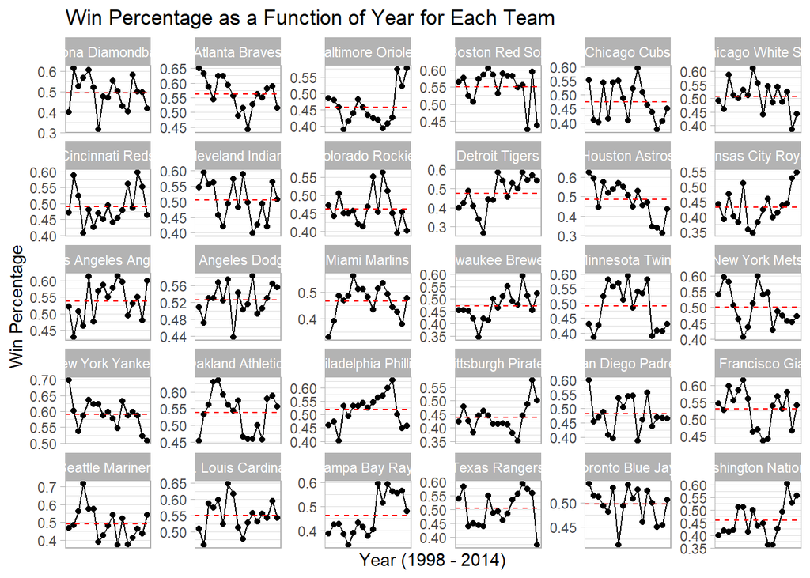

```r
mlb_yearly$year <- as.numeric(as.character(mlb_yearly$year))

ggplot(mlb_yearly, aes(x = year, y = pct_wins, group = team)) +
  geom_line() +
  geom_point() +
  geom_hline(data = mlb_yearly %>% group_by(team) %>%
               summarise(mean_pct_wins = mean(pct_wins, na.rm = TRUE), .groups = 'keep'),
             aes(yintercept = mean_pct_wins), linetype = "dashed", color = "red") +
  facet_wrap(~team, scales = "free_y") +
  theme_light() +
  labs(title = "Win Percentage as a Function of Year for Each Team", x = "Year (1998 - 2014)", y = "Win Percentage") +
  scale_x_continuous(breaks = range(mlb_yearly$year),
                     labels = c(min(mlb_yearly$year), max(mlb_yearly$year))) +
  theme(axis.text.x = element_text(angle = 0))
```

### Identifying the Three Teams with the Greatest pct_wins_aggregate_computed

```r
mlb_aggregate_computed %>%
  arrange(desc(pct_wins_aggregate_computed)) %>%
  slice_head(n = 3) %>%
  print()
```

```
## # A tibble: 3 × 3
##   team             payroll_aggregate_computed pct_wins_aggregate_computed
##   <fct>                                 <dbl>                       <dbl>
## 1 New York Yankees                      2860.                       0.591
## 2 Atlanta Braves                        1520.                       0.563
## 3 Boston Red Sox                        2106.                       0.551
```

### Identifying the Three Teams with the Most Erratic pct_wins

```r
mlb_yearly %>%
  group_by(team) %>%
  summarise(pct_wins_sd = sd(pct_wins, na.rm = TRUE)) %>%
  arrange(desc(pct_wins_sd)) %>%
  slice_head(n = 3) %>%
  print()
```

```
## # A tibble: 3 × 2
##   team             pct_wins_sd
##   <fct>                  <dbl>
## 1 Houston Astros        0.0914
## 2 Detroit Tigers        0.0898
## 3 Seattle Mariners      0.0892
```

### 2.3 Scatterplot:

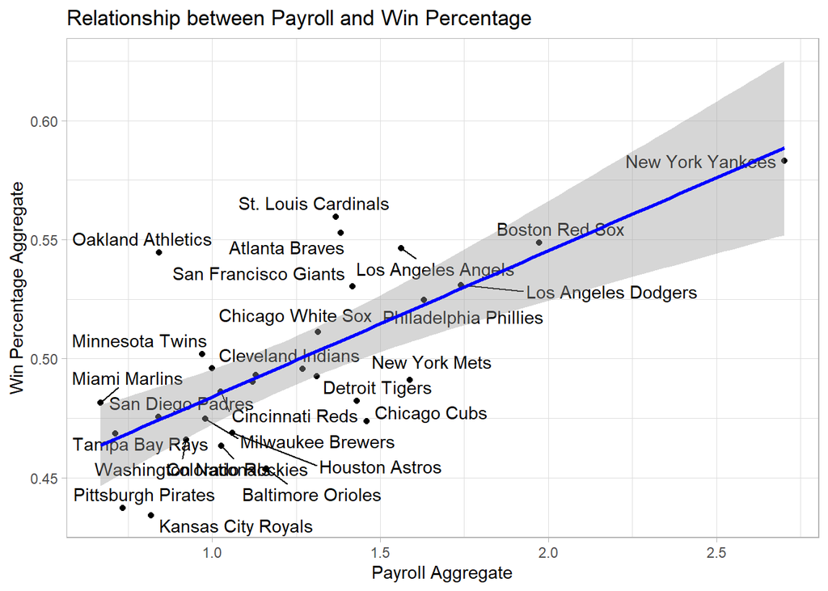

```r
ggplot(mlb_aggregate, aes(x = payroll_aggregate, y = pct_wins_aggregate, label = team)) +
  geom_point() +
  geom_text_repel() +
  geom_smooth(method = "lm", color = "blue") +
  theme_light() +
  labs(title = "Relationship between Payroll and Win Percentage",
       x = "Payroll Aggregate",
       y = "Win Percentage Aggregate")
```

### Interpretation

The relationship between payroll and win percentage in MLB is positive, as shown in the scatter plot. This aligns with expectations that financial spending can have a positive impact on a team’s performance. However, the relationship is not perfect, and there are teams that outperform or underperform relative to their payroll, wchich could indicate other variables that can affect the performance outside of the pay.

```r
mlb_aggregate_computed %>%
  mutate(efficiency = pct_wins_aggregate_computed / payroll_aggregate_computed) %>%
  arrange(desc(efficiency)) %>%
  slice_head(n = 3) %>%
  select(team, efficiency, pct_wins_aggregate_computed, payroll_aggregate_computed)
```

```
## # A tibble: 3 × 4
##   team              efficiency pct_wins_aggregate_computed payroll_aggregate_c…¹
##   <fct>                  <dbl>                       <dbl>                 <dbl>
## 1 Miami Marlins       0.000669                       0.467                  699.
## 2 Oakland Athletics   0.000606                       0.539                  888.
## 3 Tampa Bay Rays      0.000593                       0.461                  777.
## # … with abbreviated variable name ¹payroll_aggregate_computed
```

### Interpretation:

Teams that are more efficient will have a higher win percentage relative to their payroll, meaning they should appear further to the left (lower payroll) and/or higher up (higher win percentage) on the scatter plot. The most efficient teams are getting more wins per dollar spent compared to less efficient teams. In the scatter plot, these teams may not necessarily be the ones with the highest win percentage or the lowest payroll, but they will have a favorable ratio between payroll and percentage of wins.

#### Breakdown:

- Miami Marlins: With an efficiency score of approximately 0.0006688, the Miami Marlins are the most efficient team according to this metric. Their aggregate win percentage is around 46.73%, and they have a relatively low aggregate payroll of about 698.76 (the units aren’t provided, but this might be in millions of dollars). This suggests that the Marlins are able to achieve a moderate level of success without a high payroll expenditure.
- Oakland Athletics: The Athletics come in second with an efficiency score of approximately 0.0006062. Their aggregate win percentage is higher than the Marlins at around 53.85%, indicating a more successful performance record. They also have a higher aggregate payroll of about 888.41. Despite spending more than the Marlins, their higher win percentage gives them a favorable efficiency score.
- Tampa Bay Rays: The Rays have an efficiency score of approximately 0.0005934, slightly lower than the Athletics. They have an aggregate win percentage of about 46.10%, which is slightly lower than the Marlins, but their aggregate payroll of about 776.90 is also higher than the Marlins. This positions them as third most efficient among the top three.

In terms of the relationship seen in the earlier scatter plot comparing payroll to win percentage, these findings make sense. Teams like the Miami Marlins and Tampa Bay Rays, which don’t have the highest payrolls, have managed a respectable win percentage, hence their high efficiency scores. The Oakland Athletics, known for their data-driven and cost-effective approach to player recruitment and team management (as seen in the book and movie “Moneyball”), show a strong win percentage despite not having one of the top payrolls, which also contributes to their high efficiency score.

These teams appear efficient because they are able to achieve a competitive number of wins relative to the money they spend on their payrolls. In essence, efficiency scores suggest they are getting good value for the investments they make in their team rosters.